# Network Intrusion Detection Using CIC-IDS-2017

Group E: Vishal Kumar, Avanti Gupta, Shivangi Manel

2026-05-03

## 1. Introduction

This project investigates network intrusion detection using the CIC-IDS-2017 dataset published by the Canadian Institute for Cybersecurity. Cyberattacks pose a growing threat to modern infrastructure, and the ability to automatically classify malicious network traffic is a critical challenge in cybersecurity. The goal of this analysis is to determine whether network flow features can be used to accurately identify and classify different types of cyberattacks using machine learning models in R.

## 3. Research Questions

This analysis investigates the following questions. First, can network flow features accurately classify traffic as benign or as a specific attack type? Second, which features are the most important predictors of attack type? Third, how does class imbalance affect model performance, and which model handles minority attack classes better — Random Forest or XGBoost?

## 4. Descriptive Statistics

The table below summarizes key quantitative features across the dataset. Flow Bytes per second shows an extremely large range (from negative values caused by zero-duration flows up to 2 billion), reflecting the diverse nature of network traffic. Packet Length Standard Deviation and Average Packet Size similarly show high variance, suggesting that attack traffic differs substantially from normal traffic in its packet structure. Flow IAT Mean (inter-arrival time) ranges from near zero to 120 million microseconds, capturing both high-speed attack floods and slow-rate attacks.

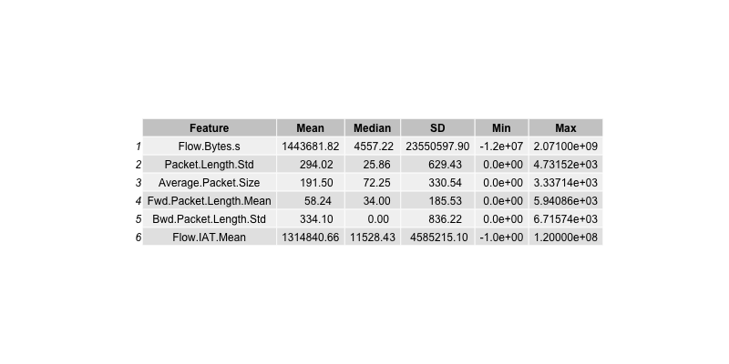

Descriptive Statistics

## 5. Class Distribution

The dataset is severely imbalanced, as shown in the figure below. Benign traffic accounts for over 2.2 million records, while some attack types are extremely rare — Infiltration has only 36 samples and SQL Injection has only 21 samples across the entire dataset. This imbalance is a fundamental challenge for classification, as models trained on such data tend to favor the majority class. A log scale is used on the y-axis to make minority classes visible.

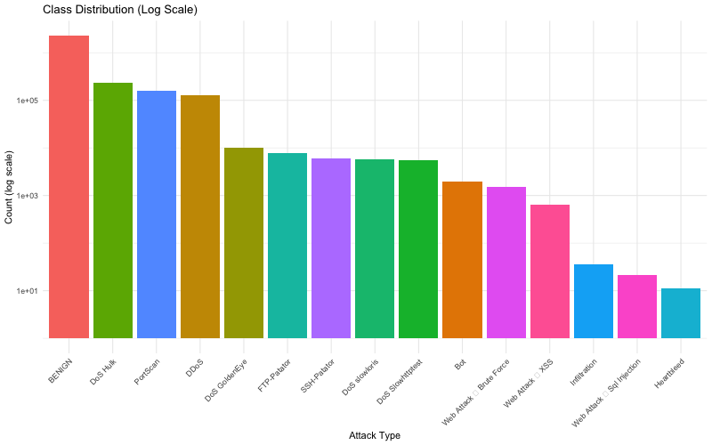

Class Distribution

## 7. Feature Importance

After training the Random Forest model, feature importance was assessed using the Mean Decrease in Gini impurity. The figure below shows the top 20 most important predictors. Packet Length Standard Deviation, Average Backward Segment Size, and Packet Length Variance are the three most discriminative features. This suggests that attacks are most distinguishable from benign traffic by the variability and size of their packets rather than their timing or port usage. Destination Port, while ranked 7th, also plays a meaningful role, consistent with the fact that certain attacks target specific ports.

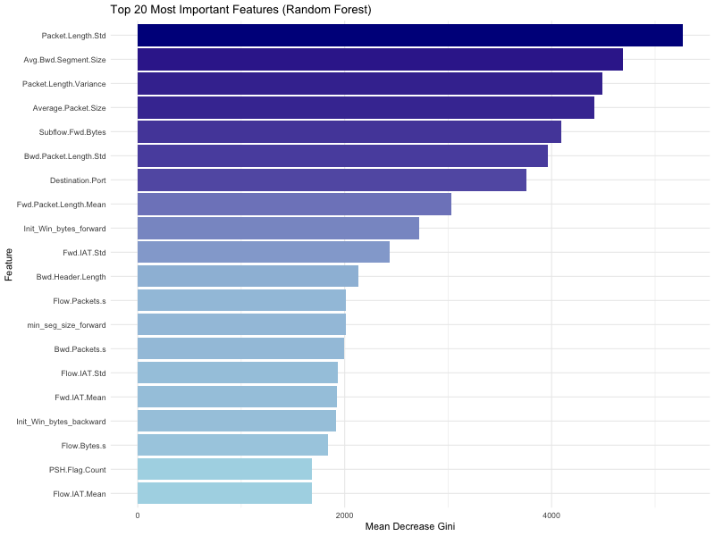

Feature Importance

## 8. Model Results

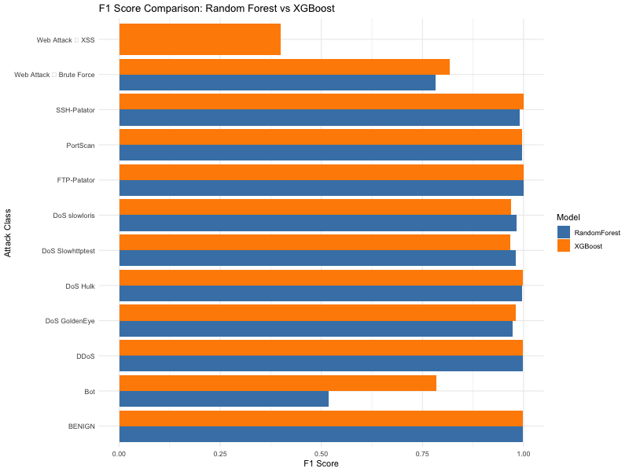

F1 Score Comparison

## 9. ROC Curve Analysis

The ROC curve below evaluates the Random Forest model ability to distinguish benign traffic from any attack type. The model achieved an AUC of 0.9998, indicating near-perfect discrimination. The curve rises sharply to the top-left corner, confirming that the model can detect attacks with very high sensitivity while maintaining an extremely low false positive rate. This is particularly important in real network environments where falsely flagging benign traffic would disrupt normal operations.

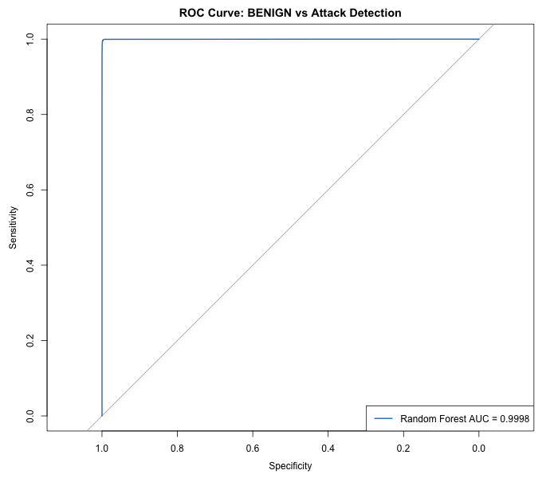

ROC Curve

## 10. Conclusion

This analysis demonstrates that machine learning models trained on network flow statistics can classify cyberattacks with high accuracy. Both Random Forest and XGBoost achieved near-perfect performance on well-represented attack types, with overall error rates below 0.2%. XGBoost outperformed Random Forest on minority attack classes, making it the preferred model for real-world deployment where rare attacks are most dangerous. The primary limitation of this analysis is severe class imbalance — attack types with very few samples could not be reliably detected. Future work should explore oversampling techniques such as SMOTE to improve minority class detection. The most important predictors were packet length statistics, confirming that attacks generate distinctive packet size patterns that distinguish them from normal traffic.